# Risk Factor Analysis

## Outcome Variable

**Outcome Variable:** pers_wast

## Predictor Variables

**Intervention Variable:** vagbrth

**Adjustment Set:**

- arm
- sex
- W_mage
- meducyrs
- feducyrs
- W_mhtcm
- W_mwtkg
- W_mbmi
- single
- brthmon
- W_parity
- delta_W_mage
- delta_meducyrs
- delta_feducyrs
- delta_W_mhtcm
- delta_W_mwtkg
- delta_W_mbmi
- delta_single
- delta_brthmon
- delta_W_parity

## Stratifying Variables

The analysis was stratified on these variable(s):

- agecat
- studyid
- country

## Data Summary

| agecat | studyid | country | vagbrth | pers_wast | n_cell | n |
| --- | --- | --- | --- | --- | --- | --- |
| 0-24 months | CMC-V-BCS-2002 | INDIA | 0 | 0 | 24 | 373 |
| 0-24 months | CMC-V-BCS-2002 | INDIA | 0 | 1 | 1 | 373 |
| 0-24 months | CMC-V-BCS-2002 | INDIA | 1 | 0 | 326 | 373 |
| 0-24 months | CMC-V-BCS-2002 | INDIA | 1 | 1 | 22 | 373 |
| 0-24 months | IRC | INDIA | 0 | 0 | 62 | 410 |
| 0-24 months | IRC | INDIA | 0 | 1 | 8 | 410 |
| 0-24 months | IRC | INDIA | 1 | 0 | 300 | 410 |
| 0-24 months | IRC | INDIA | 1 | 1 | 40 | 410 |
| 0-24 months | JiVitA-3 | BANGLADESH | 0 | 0 | 939 | 15765 |
| 0-24 months | JiVitA-3 | BANGLADESH | 0 | 1 | 57 | 15765 |
| 0-24 months | JiVitA-3 | BANGLADESH | 1 | 0 | 13931 | 15765 |
| 0-24 months | JiVitA-3 | BANGLADESH | 1 | 1 | 838 | 15765 |
| 0-24 months | JiVitA-4 | BANGLADESH | 0 | 0 | 341 | 4443 |
| 0-24 months | JiVitA-4 | BANGLADESH | 0 | 1 | 19 | 4443 |
| 0-24 months | JiVitA-4 | BANGLADESH | 1 | 0 | 3752 | 4443 |
| 0-24 months | JiVitA-4 | BANGLADESH | 1 | 1 | 331 | 4443 |
| 0-24 months | NIH-Crypto | BANGLADESH | 0 | 0 | 191 | 472 |
| 0-24 months | NIH-Crypto | BANGLADESH | 0 | 1 | 3 | 472 |
| 0-24 months | NIH-Crypto | BANGLADESH | 1 | 0 | 261 | 472 |
| 0-24 months | NIH-Crypto | BANGLADESH | 1 | 1 | 17 | 472 |
| 0-24 months | PROBIT | BELARUS | 0 | 0 | 1904 | 16583 |
| 0-24 months | PROBIT | BELARUS | 0 | 1 | 14 | 16583 |
| 0-24 months | PROBIT | BELARUS | 1 | 0 | 14545 | 16583 |
| 0-24 months | PROBIT | BELARUS | 1 | 1 | 120 | 16583 |
| 0-24 months | PROVIDE | BANGLADESH | 0 | 0 | 146 | 641 |
| 0-24 months | PROVIDE | BANGLADESH | 0 | 1 | 2 | 641 |
| 0-24 months | PROVIDE | BANGLADESH | 1 | 0 | 480 | 641 |
| 0-24 months | PROVIDE | BANGLADESH | 1 | 1 | 13 | 641 |
| 0-24 months | TanzaniaChild2 | TANZANIA, UNITED REPUBLIC OF | 0 | 0 | 192 | 2140 |
| 0-24 months | TanzaniaChild2 | TANZANIA, UNITED REPUBLIC OF | 0 | 1 | 6 | 2140 |

[output cut: 74 more lines]

The following strata were considered:

- agecat: 0-24 months, studyid: CMC-V-BCS-2002, country: INDIA
- agecat: 0-24 months, studyid: IRC, country: INDIA
- agecat: 0-24 months, studyid: JiVitA-3, country: BANGLADESH
- agecat: 0-24 months, studyid: JiVitA-4, country: BANGLADESH
- agecat: 0-24 months, studyid: NIH-Crypto, country: BANGLADESH
- agecat: 0-24 months, studyid: PROBIT, country: BELARUS
- agecat: 0-24 months, studyid: PROVIDE, country: BANGLADESH
- agecat: 0-24 months, studyid: TanzaniaChild2, country: TANZANIA, UNITED REPUBLIC OF
- agecat: 0-24 months, studyid: ZVITAMBO, country: ZIMBABWE
- agecat: 0-6 months, studyid: CMC-V-BCS-2002, country: INDIA
- agecat: 0-6 months, studyid: IRC, country: INDIA
- agecat: 0-6 months, studyid: JiVitA-3, country: BANGLADESH
- agecat: 0-6 months, studyid: NIH-Crypto, country: BANGLADESH
- agecat: 0-6 months, studyid: PROBIT, country: BELARUS
- agecat: 0-6 months, studyid: PROVIDE, country: BANGLADESH
- agecat: 0-6 months, studyid: TanzaniaChild2, country: TANZANIA, UNITED REPUBLIC OF
- agecat: 0-6 months, studyid: ZVITAMBO, country: ZIMBABWE
- agecat: 6-24 months, studyid: CMC-V-BCS-2002, country: INDIA
- agecat: 6-24 months, studyid: IRC, country: INDIA
- agecat: 6-24 months, studyid: JiVitA-3, country: BANGLADESH
- agecat: 6-24 months, studyid: JiVitA-4, country: BANGLADESH
- agecat: 6-24 months, studyid: NIH-Crypto, country: BANGLADESH
- agecat: 6-24 months, studyid: PROBIT, country: BELARUS
- agecat: 6-24 months, studyid: PROVIDE, country: BANGLADESH
- agecat: 6-24 months, studyid: TanzaniaChild2, country: TANZANIA, UNITED REPUBLIC OF
- agecat: 6-24 months, studyid: ZVITAMBO, country: ZIMBABWE

### Dropped Strata

Some strata were dropped due to rare outcomes:

- agecat: 0-24 months, studyid: CMC-V-BCS-2002, country: INDIA
- agecat: 0-24 months, studyid: NIH-Crypto, country: BANGLADESH
- agecat: 0-24 months, studyid: PROVIDE, country: BANGLADESH
- agecat: 0-6 months, studyid: JiVitA-3, country: BANGLADESH
- agecat: 0-6 months, studyid: NIH-Crypto, country: BANGLADESH
- agecat: 0-6 months, studyid: PROVIDE, country: BANGLADESH
- agecat: 0-6 months, studyid: ZVITAMBO, country: ZIMBABWE
- agecat: 6-24 months, studyid: CMC-V-BCS-2002, country: INDIA
- agecat: 6-24 months, studyid: NIH-Crypto, country: BANGLADESH
- agecat: 6-24 months, studyid: PROVIDE, country: BANGLADESH

## Methods Detail

We’re interested in the causal parameters $E[Y_a]$ for all values of $a \in \mathcal{A}$. These parameters represent the mean outcome if, possibly contrary to fact, we intervened to set all units to have $A=a$. Under the randomization and positivity assumptions, these are identified by the statistical parameters $\psi_a=E_W[E_{Y|A,W}(Y|A=a,W)]$. In addition, we’re interested in the mean of $Y$, $E[Y]$ under no intervention (the observed mean). We will estimate these parameters by using SuperLearner to fit the relevant likelihood factors – $E_{Y|A,W}(Y|A=a,W)$ and $p(A=a|W)$, and then updating our likelihood fit using a joint TMLE.

For unadjusted analyses ($W=\{\}$), initial likelihoods were estimated using Lrnr_glm to estimate the simple $E(Y|A)$ and Lrnr_mean to estimate $p(A)$. For adjusted analyses, a small library containing Lrnr_glmnet, Lrnr_xgboost, and Lrnr_mean was used.

Having estimated these parameters, we will then use the delta method to estimate relative risks and attributable risks relative to a prespecified baseline level of $A$.

# Results Detail

## Results Plots

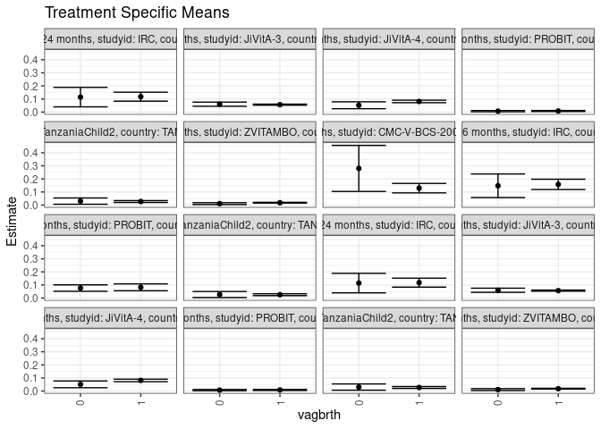

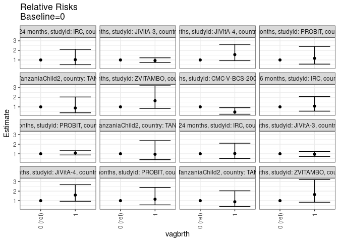

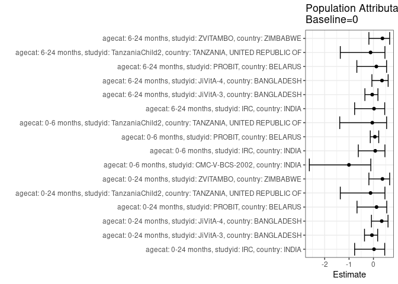

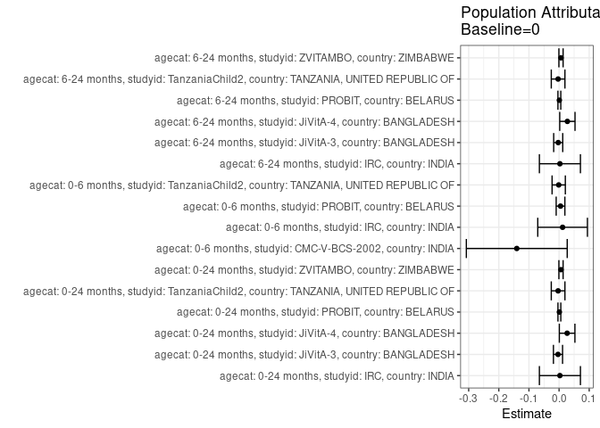

## Results Table

### Parameter: TSM

| agecat | studyid | country | intervention_level | baseline_level | estimate | ci_lower | ci_upper |
| --- | --- | --- | --- | --- | --- | --- | --- |
| 0-24 months | IRC | INDIA | 0 | NA | 0.1142857 | 0.0396628 | 0.1889086 |
| 0-24 months | IRC | INDIA | 1 | NA | 0.1176471 | 0.0833584 | 0.1519357 |
| 0-24 months | JiVitA-3 | BANGLADESH | 0 | NA | 0.0603377 | 0.0444747 | 0.0762008 |
| 0-24 months | JiVitA-3 | BANGLADESH | 1 | NA | 0.0566253 | 0.0524386 | 0.0608120 |
| 0-24 months | JiVitA-4 | BANGLADESH | 0 | NA | 0.0520222 | 0.0255592 | 0.0784852 |
| 0-24 months | JiVitA-4 | BANGLADESH | 1 | NA | 0.0811451 | 0.0715631 | 0.0907272 |
| 0-24 months | PROBIT | BELARUS | 0 | NA | 0.0070483 | 0.0024877 | 0.0116088 |
| 0-24 months | PROBIT | BELARUS | 1 | NA | 0.0082388 | 0.0043604 | 0.0121172 |
| 0-24 months | TanzaniaChild2 | TANZANIA, UNITED REPUBLIC OF | 0 | NA | 0.0303030 | 0.0064206 | 0.0541854 |
| 0-24 months | TanzaniaChild2 | TANZANIA, UNITED REPUBLIC OF | 1 | NA | 0.0267765 | 0.0195951 | 0.0339579 |
| 0-24 months | ZVITAMBO | ZIMBABWE | 0 | NA | 0.0109489 | 0.0038346 | 0.0180632 |
| 0-24 months | ZVITAMBO | ZIMBABWE | 1 | NA | 0.0179668 | 0.0151637 | 0.0207700 |
| 0-6 months | CMC-V-BCS-2002 | INDIA | 0 | NA | 0.2800000 | 0.1037493 | 0.4562507 |
| 0-6 months | CMC-V-BCS-2002 | INDIA | 1 | NA | 0.1291291 | 0.0930611 | 0.1651972 |
| 0-6 months | IRC | INDIA | 0 | NA | 0.1475098 | 0.0571367 | 0.2378828 |
| 0-6 months | IRC | INDIA | 1 | NA | 0.1580832 | 0.1187856 | 0.1973807 |
| 0-6 months | PROBIT | BELARUS | 0 | NA | 0.0762265 | 0.0516683 | 0.1007848 |
| 0-6 months | PROBIT | BELARUS | 1 | NA | 0.0819022 | 0.0556967 | 0.1081077 |
| 0-6 months | TanzaniaChild2 | TANZANIA, UNITED REPUBLIC OF | 0 | NA | 0.0267380 | 0.0036113 | 0.0498646 |
| 0-6 months | TanzaniaChild2 | TANZANIA, UNITED REPUBLIC OF | 1 | NA | 0.0254329 | 0.0182532 | 0.0326126 |
| 6-24 months | IRC | INDIA | 0 | NA | 0.1142857 | 0.0396628 | 0.1889086 |
| 6-24 months | IRC | INDIA | 1 | NA | 0.1176471 | 0.0833584 | 0.1519357 |
| 6-24 months | JiVitA-3 | BANGLADESH | 0 | NA | 0.0596050 | 0.0437988 | 0.0754112 |
| 6-24 months | JiVitA-3 | BANGLADESH | 1 | NA | 0.0567049 | 0.0525084 | 0.0609014 |
| 6-24 months | JiVitA-4 | BANGLADESH | 0 | NA | 0.0512092 | 0.0252663 | 0.0771521 |
| 6-24 months | JiVitA-4 | BANGLADESH | 1 | NA | 0.0811767 | 0.0715869 | 0.0907664 |
| 6-24 months | PROBIT | BELARUS | 0 | NA | 0.0071106 | 0.0025813 | 0.0116399 |
| 6-24 months | PROBIT | BELARUS | 1 | NA | 0.0082368 | 0.0043469 | 0.0121266 |
| 6-24 months | TanzaniaChild2 | TANZANIA, UNITED REPUBLIC OF | 0 | NA | 0.0303030 | 0.0064206 | 0.0541854 |
| 6-24 months | TanzaniaChild2 | TANZANIA, UNITED REPUBLIC OF | 1 | NA | 0.0267765 | 0.0195951 | 0.0339579 |
| 6-24 months | ZVITAMBO | ZIMBABWE | 0 | NA | 0.0109489 | 0.0038346 | 0.0180632 |
| 6-24 months | ZVITAMBO | ZIMBABWE | 1 | NA | 0.0179668 | 0.0151637 | 0.0207700 |

### Parameter: E(Y)

| agecat | studyid | country | intervention_level | baseline_level | estimate | ci_lower | ci_upper |
| --- | --- | --- | --- | --- | --- | --- | --- |
| 0-24 months | IRC | INDIA | NA | NA | 0.1170732 | 0.0859146 | 0.1482317 |
| 0-24 months | JiVitA-3 | BANGLADESH | NA | NA | 0.0567713 | 0.0526559 | 0.0608868 |
| 0-24 months | JiVitA-4 | BANGLADESH | NA | NA | 0.0787756 | 0.0696990 | 0.0878522 |
| 0-24 months | PROBIT | BELARUS | NA | NA | 0.0080806 | 0.0045539 | 0.0116073 |
| 0-24 months | TanzaniaChild2 | TANZANIA, UNITED REPUBLIC OF | NA | NA | 0.0271028 | 0.0202213 | 0.0339843 |
| 0-24 months | ZVITAMBO | ZIMBABWE | NA | NA | 0.0173563 | 0.0147230 | 0.0199897 |
| 0-6 months | CMC-V-BCS-2002 | INDIA | NA | NA | 0.1396648 | 0.1037072 | 0.1756225 |
| 0-6 months | IRC | INDIA | NA | NA | 0.1592040 | 0.1233945 | 0.1950135 |
| 0-6 months | PROBIT | BELARUS | NA | NA | 0.0810551 | 0.0555982 | 0.1065120 |
| 0-6 months | TanzaniaChild2 | TANZANIA, UNITED REPUBLIC OF | NA | NA | 0.0255528 | 0.0186952 | 0.0324104 |
| 6-24 months | IRC | INDIA | NA | NA | 0.1170732 | 0.0859146 | 0.1482317 |
| 6-24 months | JiVitA-3 | BANGLADESH | NA | NA | 0.0567713 | 0.0526559 | 0.0608868 |
| 6-24 months | JiVitA-4 | BANGLADESH | NA | NA | 0.0787756 | 0.0696990 | 0.0878522 |
| 6-24 months | PROBIT | BELARUS | NA | NA | 0.0080806 | 0.0045539 | 0.0116073 |
| 6-24 months | TanzaniaChild2 | TANZANIA, UNITED REPUBLIC OF | NA | NA | 0.0271028 | 0.0202213 | 0.0339843 |
| 6-24 months | ZVITAMBO | ZIMBABWE | NA | NA | 0.0173563 | 0.0147230 | 0.0199897 |

### Parameter: RR

| agecat | studyid | country | intervention_level | baseline_level | estimate | ci_lower | ci_upper |
| --- | --- | --- | --- | --- | --- | --- | --- |
| 0-24 months | IRC | INDIA | 0 | 0 | 1.0000000 | 1.0000000 | 1.0000000 |
| 0-24 months | IRC | INDIA | 1 | 0 | 1.0294118 | 0.5035574 | 2.1044047 |
| 0-24 months | JiVitA-3 | BANGLADESH | 0 | 0 | 1.0000000 | 1.0000000 | 1.0000000 |
| 0-24 months | JiVitA-3 | BANGLADESH | 1 | 0 | 0.9384731 | 0.7183726 | 1.2260097 |
| 0-24 months | JiVitA-4 | BANGLADESH | 0 | 0 | 1.0000000 | 1.0000000 | 1.0000000 |
| 0-24 months | JiVitA-4 | BANGLADESH | 1 | 0 | 1.5598175 | 0.9250429 | 2.6301814 |
| 0-24 months | PROBIT | BELARUS | 0 | 0 | 1.0000000 | 1.0000000 | 1.0000000 |
| 0-24 months | PROBIT | BELARUS | 1 | 0 | 1.1689116 | 0.5658796 | 2.4145672 |
| 0-24 months | TanzaniaChild2 | TANZANIA, UNITED REPUBLIC OF | 0 | 0 | 1.0000000 | 1.0000000 | 1.0000000 |
| 0-24 months | TanzaniaChild2 | TANZANIA, UNITED REPUBLIC OF | 1 | 0 | 0.8836251 | 0.3843408 | 2.0315133 |
| 0-24 months | ZVITAMBO | ZIMBABWE | 0 | 0 | 1.0000000 | 1.0000000 | 1.0000000 |
| 0-24 months | ZVITAMBO | ZIMBABWE | 1 | 0 | 1.6409721 | 0.8411810 | 3.2012011 |
| 0-6 months | CMC-V-BCS-2002 | INDIA | 0 | 0 | 1.0000000 | 1.0000000 | 1.0000000 |
| 0-6 months | CMC-V-BCS-2002 | INDIA | 1 | 0 | 0.4611755 | 0.2316258 | 0.9182174 |
| 0-6 months | IRC | INDIA | 0 | 0 | 1.0000000 | 1.0000000 | 1.0000000 |
| 0-6 months | IRC | INDIA | 1 | 0 | 1.0716794 | 0.5529919 | 2.0768781 |
| 0-6 months | PROBIT | BELARUS | 0 | 0 | 1.0000000 | 1.0000000 | 1.0000000 |
| 0-6 months | PROBIT | BELARUS | 1 | 0 | 1.0744581 | 0.8753601 | 1.3188403 |
| 0-6 months | TanzaniaChild2 | TANZANIA, UNITED REPUBLIC OF | 0 | 0 | 1.0000000 | 1.0000000 | 1.0000000 |
| 0-6 months | TanzaniaChild2 | TANZANIA, UNITED REPUBLIC OF | 1 | 0 | 0.9511905 | 0.3829381 | 2.3626880 |
| 6-24 months | IRC | INDIA | 0 | 0 | 1.0000000 | 1.0000000 | 1.0000000 |
| 6-24 months | IRC | INDIA | 1 | 0 | 1.0294118 | 0.5035574 | 2.1044047 |
| 6-24 months | JiVitA-3 | BANGLADESH | 0 | 0 | 1.0000000 | 1.0000000 | 1.0000000 |
| 6-24 months | JiVitA-3 | BANGLADESH | 1 | 0 | 0.9513444 | 0.7273589 | 1.2443047 |
| 6-24 months | JiVitA-4 | BANGLADESH | 0 | 0 | 1.0000000 | 1.0000000 | 1.0000000 |
| 6-24 months | JiVitA-4 | BANGLADESH | 1 | 0 | 1.5851976 | 0.9418539 | 2.6679842 |
| 6-24 months | PROBIT | BELARUS | 0 | 0 | 1.0000000 | 1.0000000 | 1.0000000 |
| 6-24 months | PROBIT | BELARUS | 1 | 0 | 1.1583810 | 0.5625937 | 2.3851076 |
| 6-24 months | TanzaniaChild2 | TANZANIA, UNITED REPUBLIC OF | 0 | 0 | 1.0000000 | 1.0000000 | 1.0000000 |
| 6-24 months | TanzaniaChild2 | TANZANIA, UNITED REPUBLIC OF | 1 | 0 | 0.8836251 | 0.3843408 | 2.0315133 |
| 6-24 months | ZVITAMBO | ZIMBABWE | 0 | 0 | 1.0000000 | 1.0000000 | 1.0000000 |
| 6-24 months | ZVITAMBO | ZIMBABWE | 1 | 0 | 1.6409721 | 0.8411810 | 3.2012011 |

### Parameter: PAR

| agecat | studyid | country | intervention_level | baseline_level | estimate | ci_lower | ci_upper |
| --- | --- | --- | --- | --- | --- | --- | --- |
| 0-24 months | IRC | INDIA | 0 | NA | 0.0027875 | -0.0653152 | 0.0708901 |
| 0-24 months | JiVitA-3 | BANGLADESH | 0 | NA | -0.0035664 | -0.0187134 | 0.0115807 |
| 0-24 months | JiVitA-4 | BANGLADESH | 0 | NA | 0.0267534 | 0.0009131 | 0.0525937 |
| 0-24 months | PROBIT | BELARUS | 0 | NA | 0.0010323 | -0.0037363 | 0.0058009 |
| 0-24 months | TanzaniaChild2 | TANZANIA, UNITED REPUBLIC OF | 0 | NA | -0.0032002 | -0.0258316 | 0.0194312 |
| 0-24 months | ZVITAMBO | ZIMBABWE | 0 | NA | 0.0064074 | -0.0005741 | 0.0133889 |
| 0-6 months | CMC-V-BCS-2002 | INDIA | 0 | NA | -0.1403352 | -0.3077229 | 0.0270526 |
| 0-6 months | IRC | INDIA | 0 | NA | 0.0116942 | -0.0707165 | 0.0941050 |
| 0-6 months | PROBIT | BELARUS | 0 | NA | 0.0048286 | -0.0096032 | 0.0192604 |
| 0-6 months | TanzaniaChild2 | TANZANIA, UNITED REPUBLIC OF | 0 | NA | -0.0011851 | -0.0231755 | 0.0208052 |
| 6-24 months | IRC | INDIA | 0 | NA | 0.0027875 | -0.0653152 | 0.0708901 |
| 6-24 months | JiVitA-3 | BANGLADESH | 0 | NA | -0.0028337 | -0.0178515 | 0.0121842 |
| 6-24 months | JiVitA-4 | BANGLADESH | 0 | NA | 0.0275664 | 0.0021966 | 0.0529363 |
| 6-24 months | PROBIT | BELARUS | 0 | NA | 0.0009700 | -0.0037985 | 0.0057384 |
| 6-24 months | TanzaniaChild2 | TANZANIA, UNITED REPUBLIC OF | 0 | NA | -0.0032002 | -0.0258316 | 0.0194312 |
| 6-24 months | ZVITAMBO | ZIMBABWE | 0 | NA | 0.0064074 | -0.0005741 | 0.0133889 |

### Parameter: PAF

| agecat | studyid | country | intervention_level | baseline_level | estimate | ci_lower | ci_upper |
| --- | --- | --- | --- | --- | --- | --- | --- |
| 0-24 months | IRC | INDIA | 0 | NA | 0.0238095 | -0.7714072 | 0.4620391 |
| 0-24 months | JiVitA-3 | BANGLADESH | 0 | NA | -0.0628202 | -0.3659076 | 0.1730139 |
| 0-24 months | JiVitA-4 | BANGLADESH | 0 | NA | 0.3396152 | -0.0822232 | 0.5970258 |
| 0-24 months | PROBIT | BELARUS | 0 | NA | 0.1277496 | -0.6738475 | 0.5454659 |
| 0-24 months | TanzaniaChild2 | TANZANIA, UNITED REPUBLIC OF | 0 | NA | -0.1180773 | -1.3584262 | 0.4699445 |
| 0-24 months | ZVITAMBO | ZIMBABWE | 0 | NA | 0.3691695 | -0.1863150 | 0.6645519 |
| 0-6 months | CMC-V-BCS-2002 | INDIA | 0 | NA | -1.0048000 | -2.6272555 | -0.1080617 |
| 0-6 months | IRC | INDIA | 0 | NA | 0.0734544 | -0.6208566 | 0.4703499 |
| 0-6 months | PROBIT | BELARUS | 0 | NA | 0.0595717 | -0.1297598 | 0.2171741 |
| 0-6 months | TanzaniaChild2 | TANZANIA, UNITED REPUBLIC OF | 0 | NA | -0.0463801 | -1.3814109 | 0.5402258 |
| 6-24 months | IRC | INDIA | 0 | NA | 0.0238095 | -0.7714072 | 0.4620391 |
| 6-24 months | JiVitA-3 | BANGLADESH | 0 | NA | -0.0499138 | -0.3505108 | 0.1837762 |
| 6-24 months | JiVitA-4 | BANGLADESH | 0 | NA | 0.3499360 | -0.0633968 | 0.6026100 |
| 6-24 months | PROBIT | BELARUS | 0 | NA | 0.1200373 | -0.6803648 | 0.5391868 |
| 6-24 months | TanzaniaChild2 | TANZANIA, UNITED REPUBLIC OF | 0 | NA | -0.1180773 | -1.3584262 | 0.4699445 |
| 6-24 months | ZVITAMBO | ZIMBABWE | 0 | NA | 0.3691695 | -0.1863150 | 0.6645519 |